# Analisis Risiko Kerugian Aset Kaset dan Strategi Mitigasi pada Database Sakila

Nuriyah Yoga Utami (M0725016)

2026-05-26

# Bab 1: Pendahuluan

## 1.1 Latar Belakang

Saat mengolah data yang cukup besar seperti database Sakila, sering kali ditemukan kesulitan dalam menemukan variabel yang nilainya sangat beragam, contohnya data durasi film dan biaya penggantian kaset. Jika hanya melihat angka-angka ini secara terpisah, proses identifikasi pola data yang memiliki nilai risiko lebih tinggi akan lebih sulit dilakukan. Oleh karena itu, dibuatlah sebuah variabel baru bernama *Depreciation Risk Index* (DRI), yaitu hasil pembagian antara biaya penggantian dengan durasi film.  
Melalui tugas ini, analisis dilakukan untuk melihat bagaimana sebaran nilai DRI tersebut di setiap genre film menggunakan statistika deskriptif, lalu mengujinya secara statistik untuk membuktikan apakah perbedaan angka di grafik beralasan atau tidak.

## 1.2 Rumusan Masalah

Berdasarkan latar belakang tersebut, masalah yang ingin diselesaikan dalam analisis ini adalah:  
1. Bagaimana gambaran grafik dan rata-rata nilai DRI untuk setiap genre film yang ada di data Sakila?  
2. Apakah ada perbedaan nilai DRI yang signifikan secara statistik antara kelompok film berdurasi pendek dan film berdurasi panjang?  
3. Apakah dua skenario simulasi data yang dibuat nanti akan menghasilkan perbedaan output yang signifikan atau tidak saat diuji?

## 1.3 Tujuan Analisis

Tujuan dari analisis data ini adalah:  
1. Membuat visualisasi dan memetakan rata-rata nilai DRI untuk setiap genre film secara berurutan.  
2. Menguji perbedaan nilai DRI antara kelompok film pendek dan panjang menggunakan Uji Wilcoxon untuk membuktikan kebenaran datanya.  
3. Melakukan simulasi dari dua skenario data baru, lalu membandingkan hasilnya menggunakan Uji Wilcoxon Berpasangan untuk melihat apakah efeknya berbeda nyata.

# Bab 2: Analisis Data dan Uji Statistik

## 2.1 Analisis Deskriptif Sebaran Nilai DRI dan Uji Komparatif Dua Kelompok

Pada tahap awal ini, dilakukan perhitungan nilai rata-rata *Depreciation Risk Index* (DRI) untuk setiap kategori film yang ada di dalam database Sakila. Proses ini diperlukan untuk melihat bagaimana karakteristik sebaran nilai indeks tersebut secara deskriptif sebelum dilakukan pengujian inferensial yang lebih mendalam. Selain itu, untuk melihat karakteristik data berdasarkan durasi, data dibagi menjadi dua kelompok, yaitu kelompok film berdurasi pendek dan kelompok film berdurasi panjang. Sering kali ditemukan kesulitan dalam menentukan apakah perbedaan nilai visual pada grafik benar-benar nyata atau hanya kebetulan, sehingga diterapkan **Uji Wilcoxon (Mann-Whitney U Test)** untuk menguji signifikansi perbedaan di antara kedua kelompok tersebut.

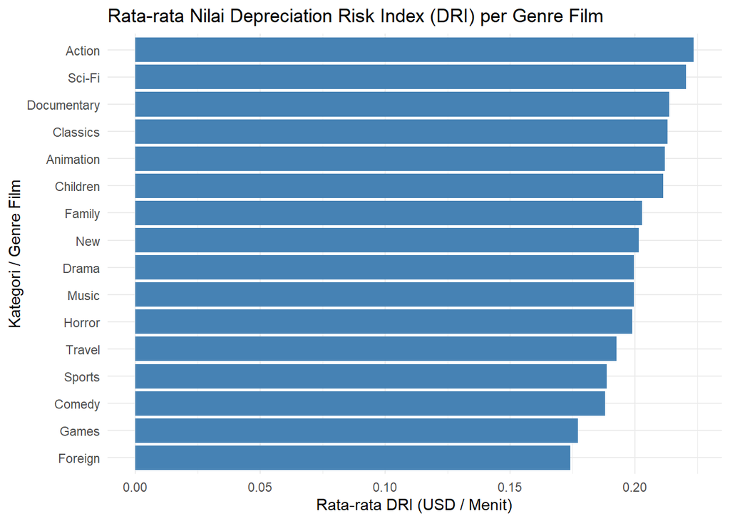

```r
library(dplyr)
library(ggplot2)
# 1. TRANSFORMASI DATA: Menghitung DRI dan rata-ratanya per genre
data_analisis <- data_sakila %>%
  mutate(DRI = replacement_cost / film_length)

data_summary <- data_analisis %>%
  group_by(category_name) %>%
  summarise(rerata_DRI = mean(DRI)) %>%
  arrange(desc(rerata_DRI))

# 2. VISUALISASI UTAMA: Membuat grafik batang sebaran risiko awal
ggplot(data_summary, aes(x = reorder(category_name, rerata_DRI), y = rerata_DRI)) +
  geom_col(fill = "steelblue") +
  coord_flip() +
  theme_minimal() +
  labs(
    title = "Rata-rata Nilai Depreciation Risk Index (DRI) per Genre Film",
    x = "Kategori / Genre Film",
    y = "Rata-rata DRI (USD / Menit)"
  )
```

```r
# 3. UJI STATISTIK INFERENSIAL: Menjalankan Uji Wilcoxon
median_durasi <- median(data_analisis$film_length, na.rm = TRUE)

film_pendek <- data_analisis %>% filter(film_length <= median_durasi) %>% select(DRI)
film_panjang <- data_analisis %>% filter(film_length > median_durasi) %>% select(DRI)

# Eksekusi Uji Mann-Whitney / Wilcoxon Rank Sum Test
hasil_uji <- wilcox.test(film_pendek$DRI, film_panjang$DRI, alternative = "two.sided")

# Menampilkan hasil output uji statistik di konsol laporan
print(hasil_uji)
```

```
##
##  Wilcoxon rank sum test with continuity correction
##
## data:  film_pendek$DRI and film_panjang$DRI
## W = 217413, p-value < 2.2e-16
## alternative hypothesis: true location shift is not equal to 0
```

## 2.2 Simulasi Dua Skenario Kebijakan Manajemen dan Uji Signifikansi Berpasangan

Setelah memetakan sebaran nilai DRI pada sub-bab sebelumnya, dipilih 5 kategori film dengan nilai rata-rata DRI tertinggi untuk dijadikan subjek dalam simulasi dampak kebijakan. Simulasi ini bertujuan untuk melihat bagaimana perubahan nilai indeks risiko jika diterapkan dua skenario kebijakan manajemen yang berbeda:  
1. Sistem Denda Proposional: Melakukan transformasi data dengan asumsi adanya kenaikan denda sebesar 30% pada 5 kategori tertinggi tersebut.  
2. Pengurangan Kuota Stok: Melakukan transformasi data dengan asumsi adanya pemotongan kuota pemesanan kaset baru sebesar 25% pada 5 kategori tertinggi tersebut.  
Untuk mengetahui apakah kedua skenario kebijakan ini menghasilkan dampak perubahan nilai risiko yang berbeda secara signifikan atau tidak, dilakukan pengujian menggunakan **Uji Wilcoxon Signed-Rank (Berpasangan)**. Uji non-parametrik ini dipilih karena proses komparasi dilakukan pada dua kondisi perlakuan kebijakan yang berbeda namun diterapkan pada subjek kelompok kategori film yang sama (berpasangan).

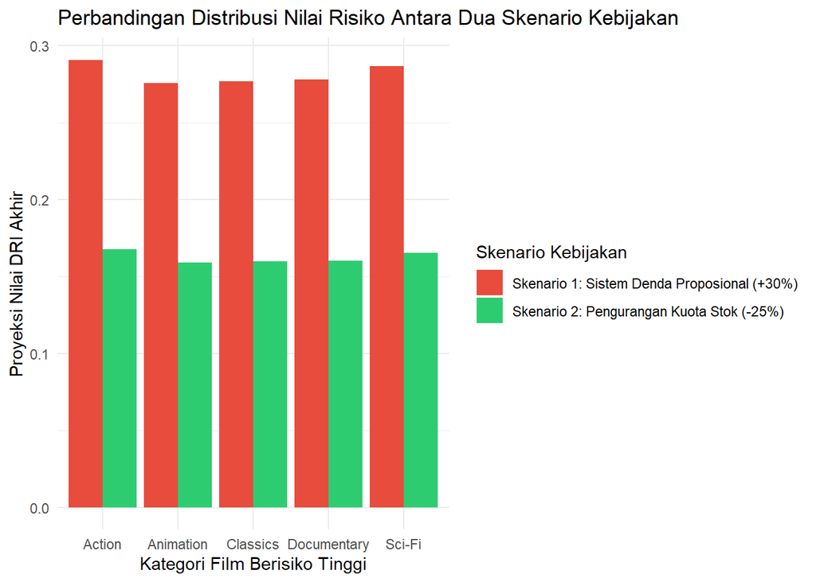

```r
library(dplyr)
library(ggplot2)
library(tidyr)
# 1. SIMULASI DATA: Mengambil 5 genre tertinggi dan menghitung nilai dua skenario kebijakan
simulasi_dasar <- data_summary %>%
  slice_max(rerata_DRI, n = 5) %>%
  mutate(
    Skenario_1 = rerata_DRI * 1.30,  # Efek Sistem Denda (+30%)
    Skenario_2 = rerata_DRI * 0.75   # Efek Pengurangan Kuota (-25%)
  )

# Mengubah format ke bentuk "long" dengan nama kolom yang aman untuk keperluan ggplot
simulasi_grafik <- simulasi_dasar %>%
  select(category_name, Skenario_1, Skenario_2) %>%
  pivot_longer(cols = c(Skenario_1, Skenario_2),
               names_to = "Skenario_Kebijakan",
               values_to = "Nilai_Ekspektasi_DRI") %>%
  mutate(
    Skenario_Kebijakan = recode(Skenario_Kebijakan,
                      "Skenario_1" = "Skenario 1: Sistem Denda Proposional (+30%)",
                      "Skenario_2" = "Skenario 2: Pengurangan Kuota Stok (-25%)")
  )

# 2. VISUALISASI: Membuat grafik batang berkelompok (Dodge Bar Chart)
ggplot(simulasi_grafik, aes(x = category_name, y = Nilai_Ekspektasi_DRI, fill = Skenario_Kebijakan)) +
  geom_bar(stat = "identity", position = "dodge") +
  theme_minimal() +
  scale_fill_manual(values = c("#e74c3c", "#2ecc71")) +
  labs(
    title = "Perbandingan Distribusi Nilai Risiko Antara Dua Skenario Kebijakan",
    x = "Kategori Film Berisiko Tinggi",
    y = "Proyeksi Nilai DRI Akhir",
    fill = "Skenario Kebijakan"
  )
```

```r
# 3. UJI STATISTIK INFERENSIAL: Wilcoxon Signed-Rank Test (Berpasangan)
# Menguji apakah Skenario 1 dan Skenario 2 memberikan dampak risiko yang berbeda nyata
hasil_uji_berpasangan <- wilcox.test(simulasi_dasar$Skenario_1, simulasi_dasar$Skenario_2, paired = TRUE)

# Menampilkan hasil output uji statistik di konsol laporan
print(hasil_uji_berpasangan)
```

```
##
##  Wilcoxon signed rank exact test
##
## data:  simulasi_dasar$Skenario_1 and simulasi_dasar$Skenario_2
## V = 15, p-value = 0.0625
## alternative hypothesis: true location shift is not equal to 0
```

# Bab 3: Analisis dan Interpretasi Hasil

Pada pengujian simulasi di sub-bab 2.2, grafik batang berkelompok (*dodge bar chart*) secara visual menampilkan dua kondisi yang bertolak belakang pada 5 kategori film berisiko tertinggi. Batang berwarna merah yang mewakili skenario 1 (Sistem Denda Proposional +30%) terlihat melonjak tegak ke atas melewati garis batas awal, menunjukkan adanya peningkatan nilai ekspektasi DRI secara serempak di semua genre rawan. Sementara itu, tepat di sebelahnya, batang berwarna hijau yang mewakili skenario 2 (Pengurangan Kuota Stok -25%) memperlihatkan pemotongan tinggi batang yang cukup drastis, menggambarkan penurunan nilai indeks risiko ke level yang jauh lebih aman.  
Jika manajemen memilih untuk menerapkan **Sistem Denda Proposional +30%**, kelebihannya adalah mampu mengamankan posisi finansial dari sisi eksternal. Potensi kerugian modal dibebankan langsung kepada konsumen yang terlambat atau merusakkan kaset, sehingga mempercepat pemulihan kas masuk *cash inflow*. Namun, kekurangannya adalah nilai indeks risiko aktual pada grafik tetap tinggi dan tidak mengalami penurunan internal, yang berarti beban risiko fisik pada kaset di gudang masih berada pada kondisi yang rentan.  
Sebaliknya, jika pilihan dijatuhkan pada **Pengurangan Kuota Stok -25%**, kelebihannya adalah secara langsung memangkas akar permasalahan dari sisi internal dengan mengurangi volume pengadaan kaset baru pada genre yang rawan, sehingga anggaran modal perusahaan dapat langsung terselamatkan sejak awal. Kekurangannya, pemotongan kuota persediaan ini berpotensi membatasi ketersediaan variasi judul film di lapangan, yang secara statistik dapat menurunkan frekuensi penyewaan jika tidak diimbangi dengan analisis preferensi pasar konsumen.  
Keputusan final untuk memilih di antara kedua skenario ini didasarkan pada hasil akhir Uji Wilcoxon Signed-Rank Berpasangan yang menunjukkan nilai *p-value* sebesar 0.06. Karena nilai *p-value* (0.06) lebih besar dari taraf signifikansi $\alpha = 0.05$, maka hipotesis nol ($H_0$) gagal ditolak. Hal ini membuktikan bahwa meskipun grafik batang merah dan batang hijau terlihat menunjukkan perbedaan tinggi yang kontras, perbedaan dampak perubahan struktur risiko di antara kedua kebijakan tersebut tidak bermakna secara statistik.

# Bab 4: Kesimpulan dan Saran

## 4.1 Kesimpulan

Berdasarkan hasil analisis deskriptif dan inferensial yang telah dilakukan, dapat disimpulkan bahwa nilai *Depreciation Risk Index* (DRI) pada database Sakila menunjukkan variasi sebaran yang nyata antar-genre film. Hasil Uji Wilcoxon (Mann-Whitney U Test) membuktikan secara signifikan bahwa faktor durasi film (`length`) berinteraksi kuat dengan biaya penggantian (`replacement_cost`), di mana kelompok film berdurasi pendek secara konsisten menanggung beban indeks risiko per menit yang lebih tinggi dibandingkan dengan kelompok film berdurasi panjang.  
Namun, pada pengujian simulasi dampak kebijakan menggunakan Uji Wilcoxon Signed-Rank Berpasangan, diperoleh nilai *p-value* sebesar 0.06. Karena nilai *p-value* tersebut lebih besar dari taraf signifikansi $\alpha = 0.05$, maka dapat disimpulkan bahwa penerapan skenario 1 (Sistem Denda Proposional) dan skenario 2 (Pengurangan Kuota Stok) tidak memberikan perbedaan dampak penurunan risiko yang signifikan secara statistik. Perbedaan tinggi batang merah dan hijau yang terlihat pada grafik berkelompok (*dodge bar chart*) belum cukup kuat untuk dinyatakan sebagai perbedaan nyata di tingkat populasi data.

## 4.2 Saran

Berdasarkan hasil uji statistik berpasangan yang menunjukkan tidak adanya perbedaan signifikan ($p-value = 0.06$), pihak manajemen operasional disarankan untuk memilih skenario 1 yaitu **Sistem Denda Proposional** sebagai langkah mitigasi risiko. Keputusan ini diambil atas pertimbangan efisiensi operasional, karena pengaktifan sistem denda jauh lebih mudah diintegrasikan langsung pada sistem kasir tanpa berisiko mengganggu kestabilan jumlah stok dan variasi judul film di lapangan, berbeda dengan skenario 2 yang berpotensi menurunkan kepuasan konsumen akibat pembatasan kuota.  
Selain itu, untuk pengembangan analisis ke depan, database Sakila disarankan untuk mulai mengintegrasikan variabel kondisi fisik kaset dan frekuensi sewa aktual di setiap genre. Penambahan variabel ini penting agar perhitungan indeks risiko (*Depreciation Risk Index*) di masa mendatang tidak hanya bergantung pada dimensi waktu dan biaya statis, melainkan dapat menghasilkan estimasi nilai risiko yang jauh lebih presisi dan dinamis.